# Language Typology & Geography | Data Description

Language Typology Project Group

11/16/2020

# PART 1 | Describing Language Data

### Language | Glottalized Consonants

The relationship between glottalized consonants, including ejectives, and the elevation of where a language is spoken was explored in Everett (2013). The author hypothesized that ejective phonemes are more likely to occur in areas of high elevation; producing ejective sounds is characterized by the compression of air, and the associated decrease in ambient air pressure reduces the physiological effort for the production. Everett’s analysis revealed a the direct influence of a geographic factor (elevation) on the basic inventories of glottalized consonants.

The following code draws a world map using `geom_path`.

```r
world = map_data("world")
no.ejectives = by_language %>% filter(glot_features == '1 - No glottalized consonants')
worldmap.with.no.glottalized.c = ggplot(world, aes(x=long, y=lat, group=group))+
  geom_path()+
  scale_y_continuous(breaks=(-2:2) * 30)+
  scale_x_continuous(breaks=(-4:4) * 45)+
  geom_point(data = no.ejectives,
             aes(x=longitude, y=latitude),
             inherit.aes = FALSE,
             color = 'blue',
             size = 0.9)+
  theme_bw()+
  labs(title = "Map of Languages with No Glottalized Consonants")
```

The first map below visualizes where languages without any glottalized consonants are located.

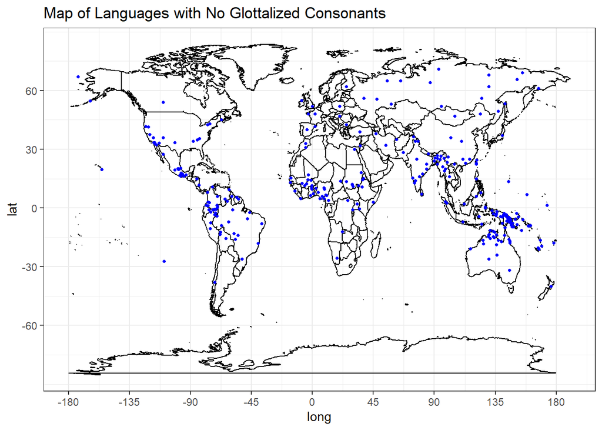

```r
#display the map
worldmap.with.no.glottalized.c
```

Next, Here is a map that illustrates the locations of the languages with glottalized consonants.

```r
ejectives = by_language %>% filter(!(glot_features == '1 - No glottalized consonants'))

worldmap.with.glottalized.c = ggplot(world, aes(x=long, y=lat, group=group))+
  geom_path()+
  scale_y_continuous(breaks=(-2:2) * 30)+
  scale_x_continuous(breaks=(-4:4) * 45)+
  geom_point(data = ejectives,
             aes(x=longitude, y=latitude),
             inherit.aes = FALSE,
             color = 'red',
             size = 0.9)+
  theme_bw()+
  labs(title = "Map of Languages with Glottalized Consonants")
```

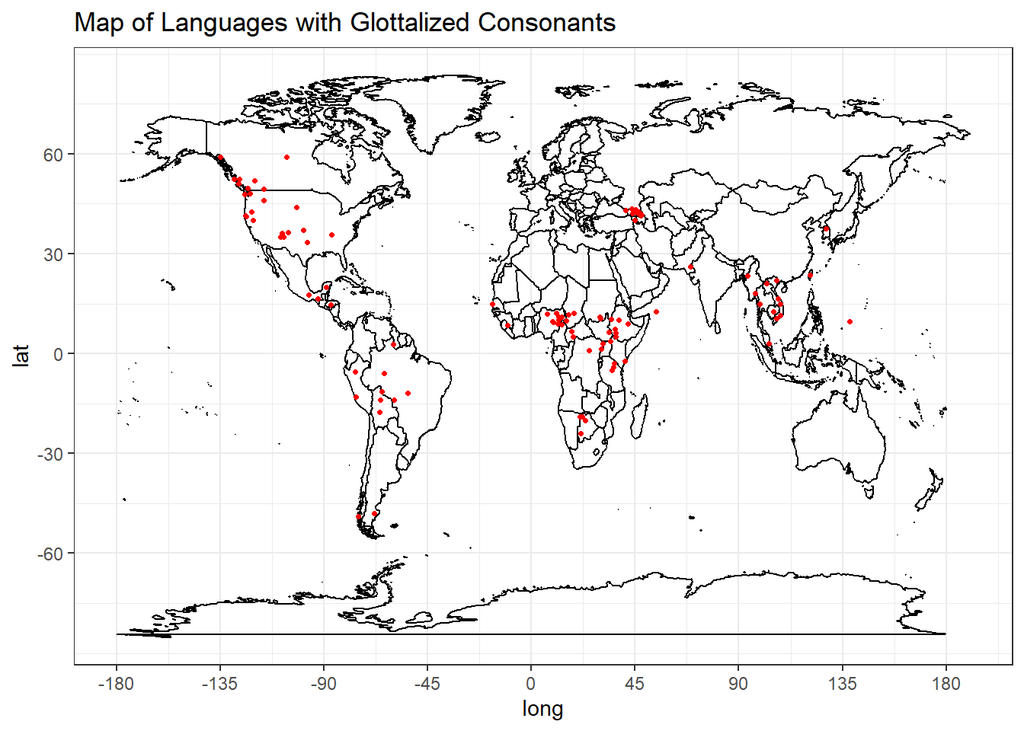

```r
#display the map
worldmap.with.glottalized.c
```

And here is the above two plots combined.

```r
worldmap.combined.ejectives = ggplot(world, aes(x=long, y=lat, group=group))+
  geom_path()+
  scale_y_continuous(breaks=(-2:2) * 30)+
  scale_x_continuous(breaks=(-4:4) * 45)+
  geom_point(data = no.ejectives,
             aes(x=longitude, y=latitude),
             inherit.aes = FALSE,
             color = 'blue',
             alpha = 0.8,
             size = 0.75)+
  geom_point(data = ejectives,
             aes(x=longitude, y=latitude),
             inherit.aes = FALSE,
             color = 'red',
             alpha = 0.8,
             size = 0.75)+
  theme_bw()+
  labs(title = "Map of Languages with & without Glottalized Consonants combined")
```

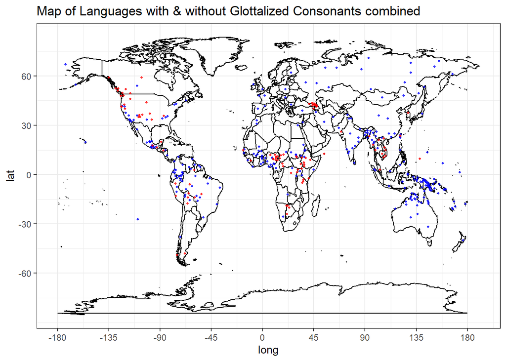

```r
#display the map
worldmap.combined.ejectives
```

### Language | Consonant-Vowel Ratio

The consonant-vowel (CV) ratio informs us of the number of consonants a language has in relation to the number of vowels. If a language has a small number of consonants, their CV ratio is low; if a language has a large number of consonants, their CV ratio is high. CV ratio of a language has been attributed to environmental factors. Sundarrajan et al. (2017) argue that the dryness between vocal folds from the ambient climate leads to the perceived phonatory effort on the part of the speaker in vowel productions. Everett (2017) examined whether a language spoken in an environment with high humidity has a lower CV ratio than the one spoken in a dry environment, and revealed a significant correlation between CV ratio and humidity.

Here is a visualization of languages with extreme high and low Consonant - Vowel ratios.

```r
cvratio.low = by_language %>% filter(cv_ratio == '1 - Low')
cvratio.high = by_language %>% filter(cv_ratio == '5 - High')
suppressMessages(glimpse(by_language))
#generate the map

world = map_data("world")
worldmap.combined.cvratio = ggplot(world, aes(x=long, y=lat, group=group))+
  geom_path()+
  scale_y_continuous(breaks=(-2:2) * 30)+
  scale_x_continuous(breaks=(-4:4) * 45)+
  geom_point(data = cvratio.low,
             aes(x=longitude, y=latitude),
             inherit.aes = FALSE,
             color = 'blue',
             alpha = 0.8,
             size = 0.9)+
  geom_point(data = cvratio.high,
             aes(x=longitude, y=latitude),
             inherit.aes = FALSE,
             color = 'red',
             alpha = 0.8,
             size = 0.9)+
  labs(title = "Map of Language with High(red) and Low(blue) Consonant-Value Ratios")+
  theme_bw()
```

[output not shown]

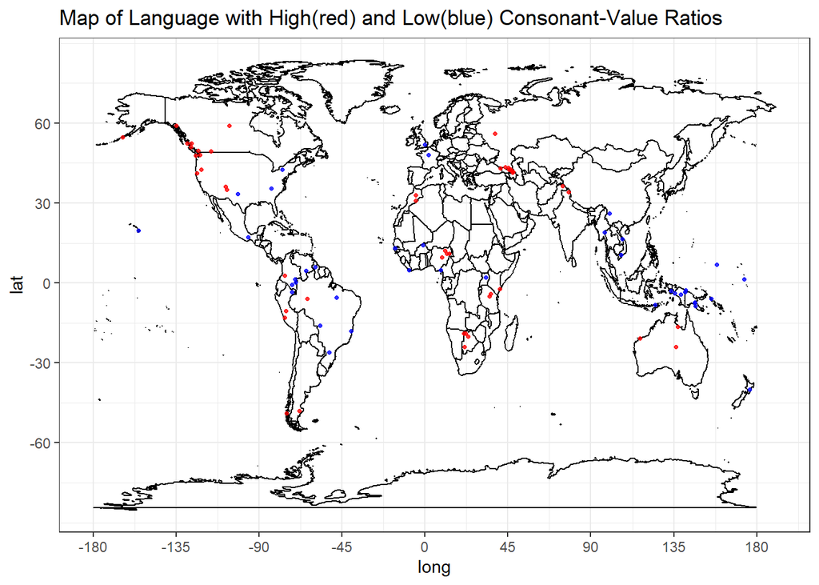

```r
#display the map
worldmap.combined.cvratio
```

```r
cvratio.low = by_language %>% filter(cv_ratio == '1 - Low')
cvratio.mod.low = by_language %>% filter(cv_ratio == '2 - Moderately low')
cvratio.ave = by_language %>% filter(cv_ratio == '3 - Average')
cvratio.mod.high = by_language %>% filter(cv_ratio == '4 - Moderately high')
cvratio.high = by_language %>% filter(cv_ratio == '5 - High')

table(by_language$cv_ratio)
#generate the map

world = map_data("world")
worldmap.combined.cvratio.all = ggplot(world, aes(x=long, y=lat, group=group))+
  geom_path()+
  scale_y_continuous(breaks=(-2:2) * 30)+
  scale_x_continuous(breaks=(-4:4) * 45)+
  geom_point(data = cvratio.low,
             aes(x=longitude, y=latitude),
             inherit.aes = FALSE,
             color = 'blue',
             alpha = 0.5,
             size = 1.2)+
  geom_point(data = cvratio.mod.low,
             aes(x=longitude, y=latitude),
             inherit.aes = FALSE,
             color = 'red',
             alpha = 0.5,
             size = 1.2)+
  geom_point(data = cvratio.ave,
             aes(x=longitude, y=latitude),
             inherit.aes = FALSE,
             color = 'purple',
             alpha = 0.5,
             size = 1.2)+
  geom_point(data = cvratio.mod.high,
             aes(x=longitude, y=latitude),
             inherit.aes = FALSE,
             color = 'dark green',
             alpha = 0.5,
             size = 1.2)+
  geom_point(data = cvratio.high,
             aes(x=longitude, y=latitude),
             inherit.aes = FALSE,
             color = 'orange',
             alpha = 0.5,
             size = 1.2)+
  labs(title = "Map of Language with Consonant-Vowel Ratio", subtitle="Low (Blue), Moderately Low (Red), Average (Purple), Moderately High (Green), High (Orange)")+
  theme_bw()
```

[output not shown]

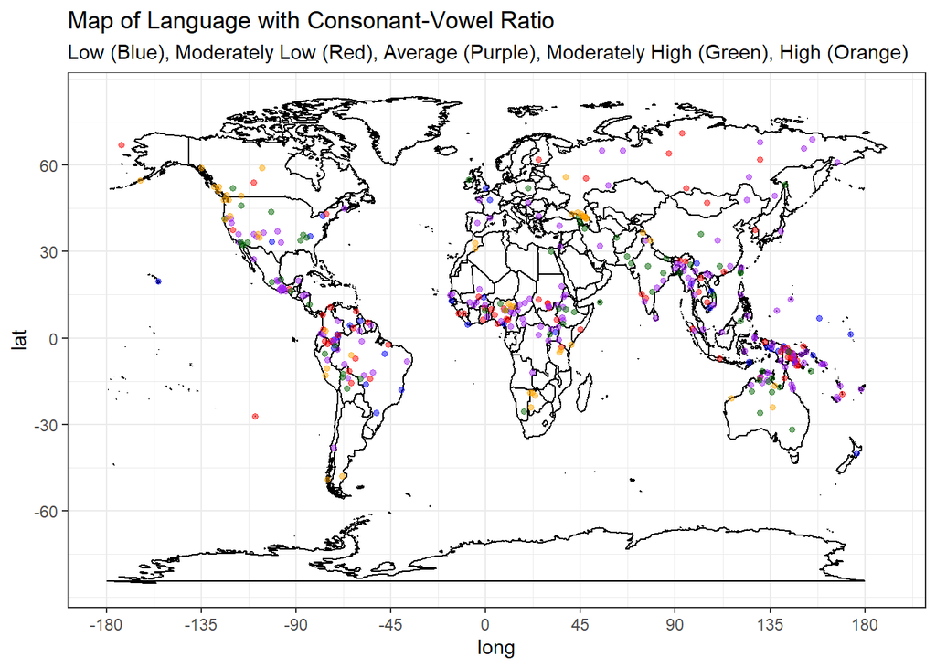

```r
worldmap.combined.cvratio.all
```

**Tone** is used to describe the use of pitch patterns to differentiate lexical or grammatical meaning. All verbal languages use pitch to express emotional information, emphasis or contrast, which is called **intonation**, but not all languages use tones to distinguish words or grammatical forms. World languages can be divided into three as to tonal system they have. The first distinction is between languages with and without tones. Languages with tones can also be categorized into two as languages with simple tone system (i.e., languages with a clear word-level pitch phenomena, but with limited function) and with complex tone system (i.e., languages with complex set of contrasts). Right below is a world map visualizing the tonal system distribution of world languages.

Everett et al. (2014) explored the relationship between climate and tonal languages. The major claim is that languages with complex tonality have generally not developed in very cold climates since desiccated air makes tonal systems harder to produce.

[output not shown]

[output cut: 16 more lines]

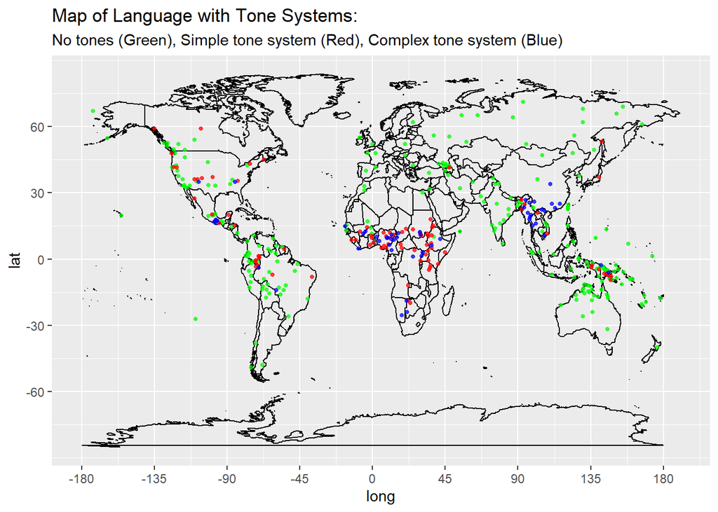

```r
#display the map
worldmap.combined.tones
```

```r
table(by_language$continent)
```

```
##
##           Africa        Australia        C America      E N America
##               83               24               20               21
##         N-C Asia   NG and Oceania        S America        S/SE Asia
##               25               55               53               56
## W and SW Eurasia      W N America
##               25               20
```

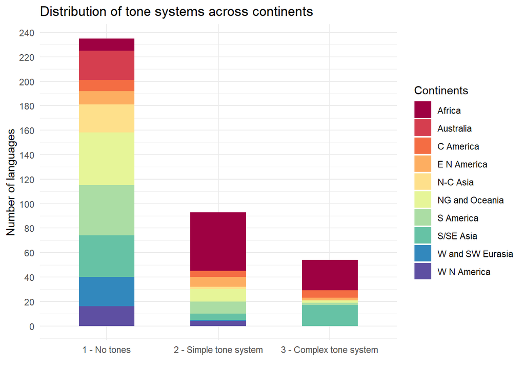

```r
across.continents.tone <- by_language %>%
  ggplot(aes(x=tones, fill=continent))+
  scale_fill_brewer(palette = "Spectral")+
  geom_bar(width=0.5)+
  theme_minimal()+
  labs(title="Distribution of tone systems across continents",
       x="",
       y="Number of languages",
       fill="Continents")+
  scale_y_continuous(breaks=seq(0,300,20))
across.continents.tone
```

### Autotyp Database

```r
suppressMessages(str(by_language)) #AUTOTYP gives us continent and area information
```

```
## tibble [382 x 29] (S3: tbl_df/tbl/data.frame)
##  $ wals_code    : chr [1:382] "xoo" "ani" "abk" "acm" ...
##  $ ISO639.3     : chr [1:382] "nmn" "hnh" "abk" "acv" ...
##  $ iso_code     : chr [1:382] "nmn" "hnh" "abk" "acv" ...
##  $ name         : chr [1:382] "!Xv=vµ" "//Ani" "Abkhaz" "Achumawi" ...
##  $ genus        : chr [1:382] "Tu" "Khoe-Kwadi" "Northwest Caucasian" "Palaihnihan" ...
##  $ subfamily    : chr [1:382] NA NA NA NA ...
##  $ family       : chr [1:382] "Tu" "Khoe-Kwadi" "Northwest Caucasian" "Hokan" ...
##  $ lsbranch     : chr [1:382] NA NA "Abkhaz-Abaza" NA ...
##  $ ssbranch     : chr [1:382] NA NA NA NA ...
##  $ sbranch      : chr [1:382] NA NA NA NA ...
##  $ mbranch      : chr [1:382] NA "Kalahari" "Abkhazian-Ubykh" NA ...
##  $ stock        : chr [1:382] "!Ui-Taa" "Kwadi-Khoe" "West Caucasian" "Palaihninan" ...
##  $ elev_ft      : num [1:382] 3750 3258 676 4931 6236 ...
##  $ elev_m       : num [1:382] 1143 993 206 1503 1901 ...
##  $ latitude     : num [1:382] -24 -18.9 43.1 41.5 34.9 ...
##  $ longitude    : num [1:382] 21.5 21.9 41 -121 -107.6 ...
##  $ countrycodes : chr [1:382] "BW" "BW" "GE" "US" ...
##  $ area         : chr [1:382] "S Africa" "S Africa" "Greater Mesopotamia" "Basin and Plains" ...
##  $ macroarea    : chr [1:382] "Africa" "Africa" "Eurasia" "North America" ...
##  $ continent    : chr [1:382] "Africa" "Africa" "W and SW Eurasia" "W N America" ...
##  $ glot_features: chr [1:382] "6 - Ejectives and glottalized resonants" "2 - Ejectives only" "2 - Ejectives only" "1 - No glottalized consonants" ...
##  $ cv_ratio     : chr [1:382] "5 - High" "5 - High" "5 - High" "3 - Average" ...
##  $ tones        : chr [1:382] "3 - Complex tone system" "2 - Simple tone system" "1 - No tones" "2 - Simple tone system" ...
##  $ rangesize    : num [1:382] 90000 739 4491 632 2018 ...
##  $ population   : num [1:382] 4200 1000 105000 16 3390 26700 8300000 5350 1530 18 ...
##  $ vehicularity : num [1:382] 0 0 1 0 0 0 1 0 0 0 ...
##  $ L2prop       : num [1:382] 0 0 NA 0 0 ...
##  $ H            : num [1:382] NA NA NA NA NA ...
##  $ H_unigram    : num [1:382] NA NA NA NA NA ...
```

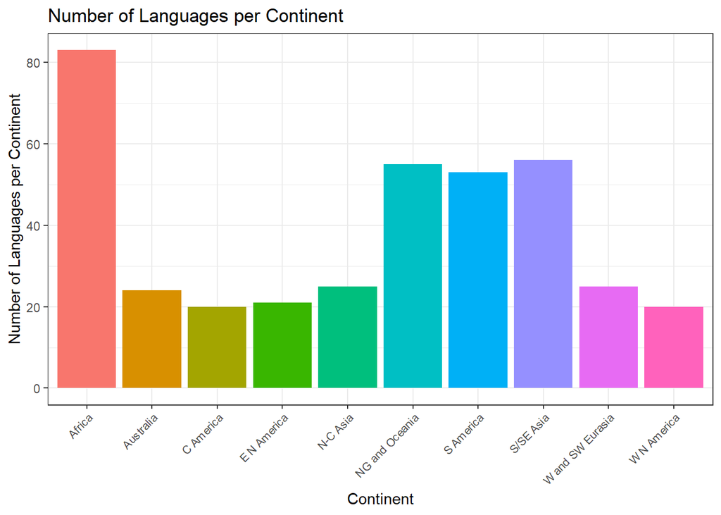

```r
autotyp_plot <- by_language %>%
  group_by(continent) %>%
  summarise(n = n())
ggplot(autotyp_plot, aes(x = continent, y = n, fill = continent)) +
  geom_bar(stat = "identity") +
  labs(x = "Continent", y="Number of Languages per Continent", color = "Continent", title = "Number of Languages per Continent") +
  theme_bw() +
  theme(axis.text.x=element_text(angle = 45, size = 8,hjust = 1), legend.position = "none")
```